# R Notebook

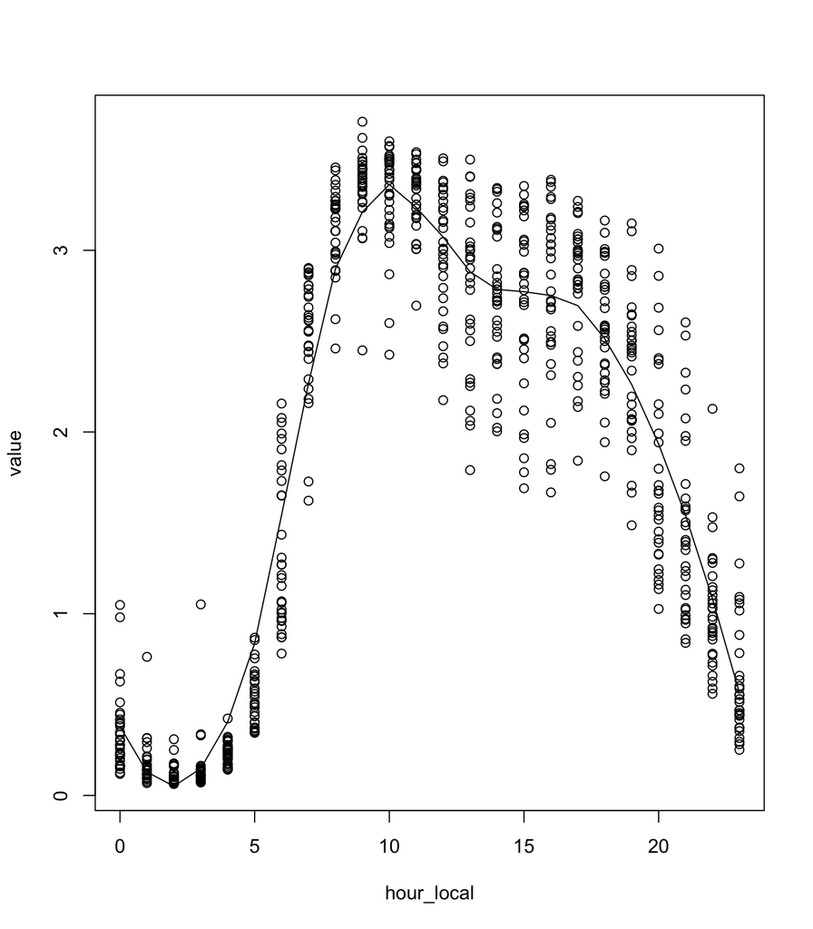

```r
with(dat_svd_stable, {
  plot(hour_local, value)

  idx <- order(hour_local)
  lines(hour_local[idx], m_tod_2$fitted[idx])
})
```

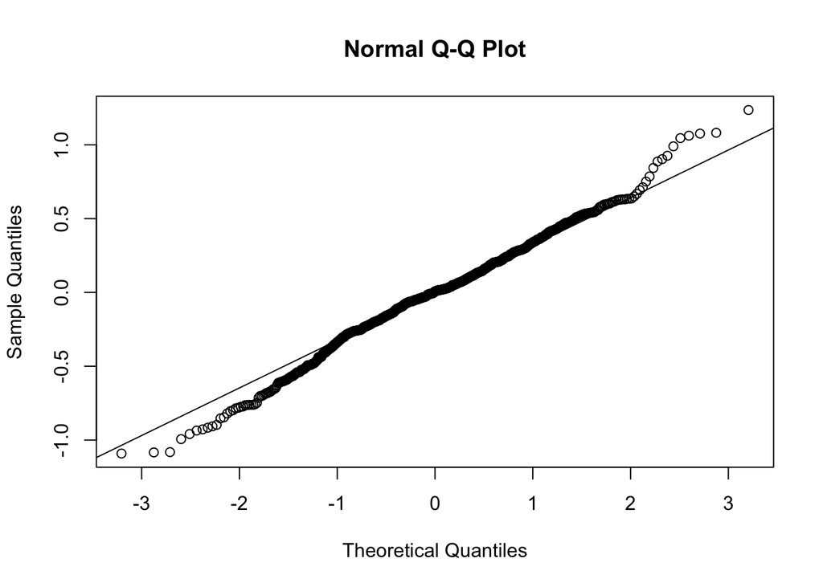

```r
qqnorm(resid(m_tod_2))
qqline(resid(m_tod_2))
```

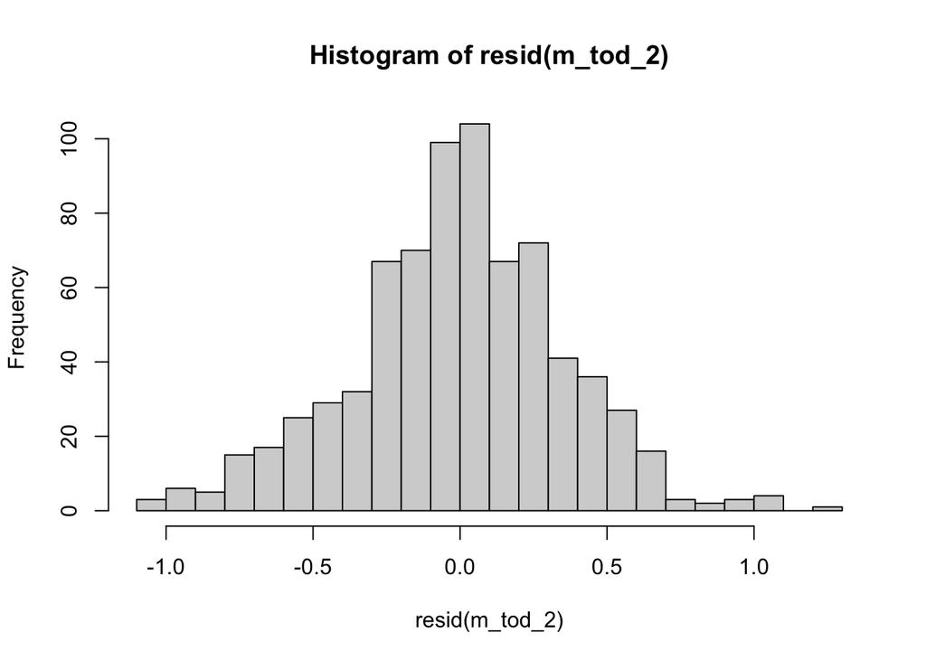

```r
hist(resid(m_tod_2), breaks = 30)
```

LOESS is sufficient for now.

```r
tz_transitions <- dat_hour %>%
  filter(timezone != lag(timezone) | timestamp == min(timestamp)) %>%
  select(timezone, utc_offset, timestamp)

tz_transitions
```

| timezone | utc_offset | timestamp |
| --- | --- | --- |
| UTC-06:00 | -6 | 2023-12-10 19:00:00 |
| UTC+09:00 | 9 | 2023-12-28 08:00:00 |
| UTC+08:00 | 8 | 2024-01-07 07:00:00 |
| UTC-08:00 | -8 | 2024-01-17 15:00:00 |
| UTC-06:00 | -6 | 2024-01-17 20:00:00 |
| UTC-05:00 | -5 | 2024-03-10 09:00:00 |
| UTC+02:00 | 2 | 2024-03-31 07:00:00 |
| UTC-05:00 | -5 | 2024-04-29 18:00:00 |
| UTC+01:00 | 1 | 2024-06-01 12:00:00 |
| UTC-04:00 | -4 | 2024-06-08 14:00:00 |

[output cut: 10 more lines]

```r
dat_svd_local <- dat_svd %>%
  mutate(timestamp = as_datetime(date) + hours(hour)) %>%
  full_join(tz_transitions, by = c("timestamp")) %>%
  arrange(timestamp) %>%
  fill(c(timezone, utc_offset), .direction = "downup") %>%
  mutate(
    hour_local = (hour + utc_offset) %% 24,
    hour_utc_min6 = (hour - 6) %% 24
  ) %>%
  drop_na()

dat_svd_local
```

```r
dat_svd_predict_tod <- dat_svd_local %>%
  add_column(
    predicted = predict(m_tod_2, newdata = dat_svd_local),
    predicted_utc_min6 = predict(m_tod_2, newdata = mutate(dat_svd_local, hour_local = hour_utc_min6))
  ) %>%
  mutate(
    error = value - predicted,
    error_utc_min6 = value - predicted_utc_min6,
    sq_error = error^2,
    sq_error_utc_min6 = error_utc_min6^2
  )

dat_svd_predict_tod

dat_svd_predict_daily <- dat_svd_predict_tod %>%
  group_by(date) %>%
  summarize(
    sq_error = mean(sq_error),
    sq_error_utc_min6 = mean(sq_error_utc_min6),
    timezone = last(timezone),
    cos_sim = first(cos_sim)
  )

dat_svd_predict_daily
```

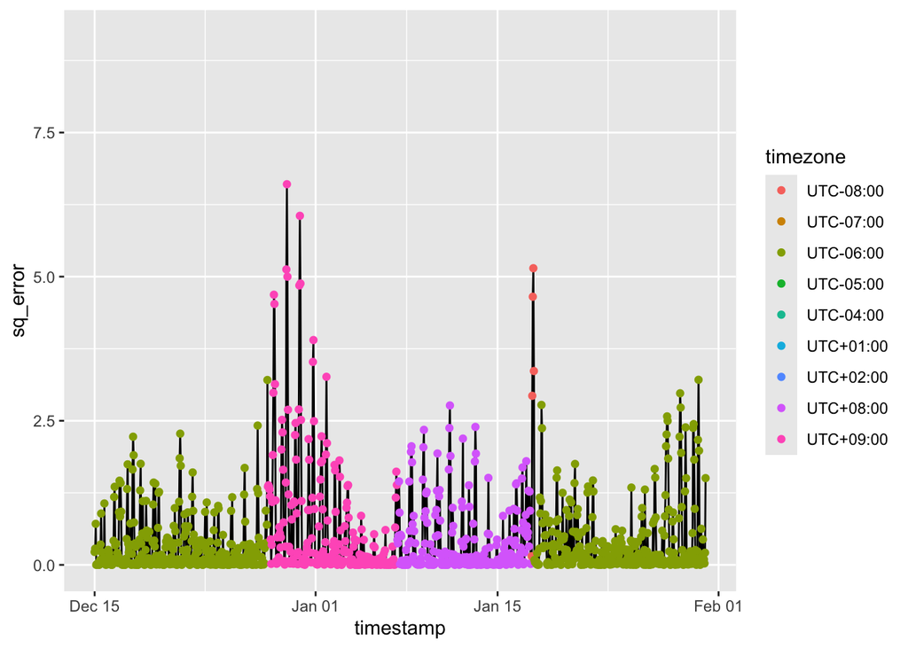

```r
ggplot(dat_svd_predict_tod, aes(timestamp, sq_error)) +
  geom_line() +
  geom_point(aes(color = timezone)) +
  xlim(zoom_start_dt, zoom_end_dt)
```

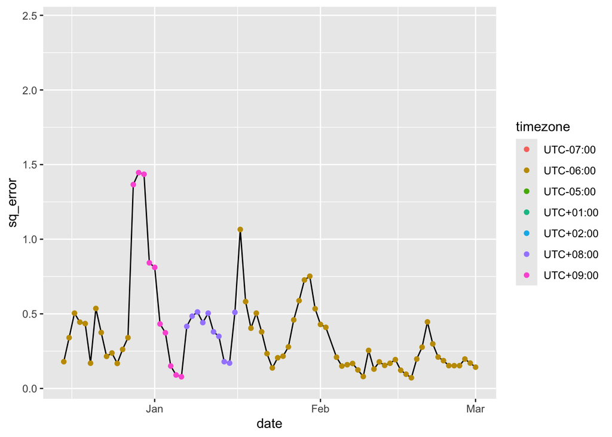

```r
ggplot(dat_svd_predict_daily, aes(date, sq_error)) +
  geom_line() +
  geom_point(aes(color = timezone)) +
  xlim(zoom_start, ymd("2024-03-01"))
```

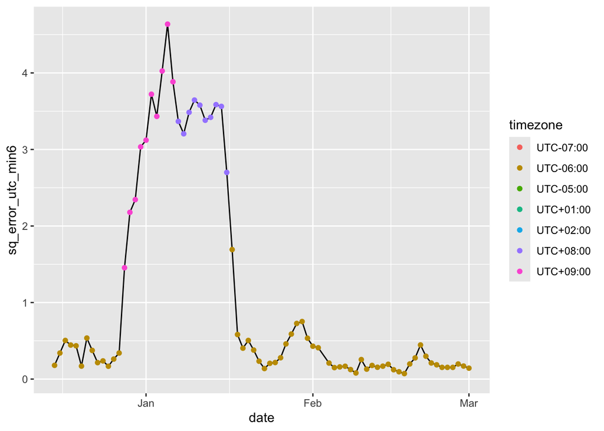

```r
ggplot(dat_svd_predict_daily, aes(date, sq_error_utc_min6)) +
  geom_line() +
  geom_point(aes(color = timezone)) +
  xlim(zoom_start, ymd("2024-03-01"))
```

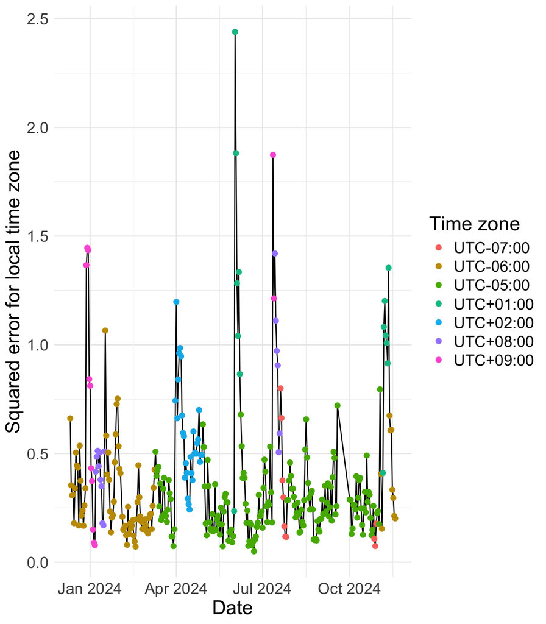

```r
ggplot(dat_svd_predict_daily, aes(date, sq_error)) +
  geom_line() +
  geom_point(aes(color = timezone), size = 2) +
  theme_minimal() +
  labs(x = "Date", y = "Squared error for local time zone", color = "Time zone") +
  theme(text = element_text(size = 18))
```

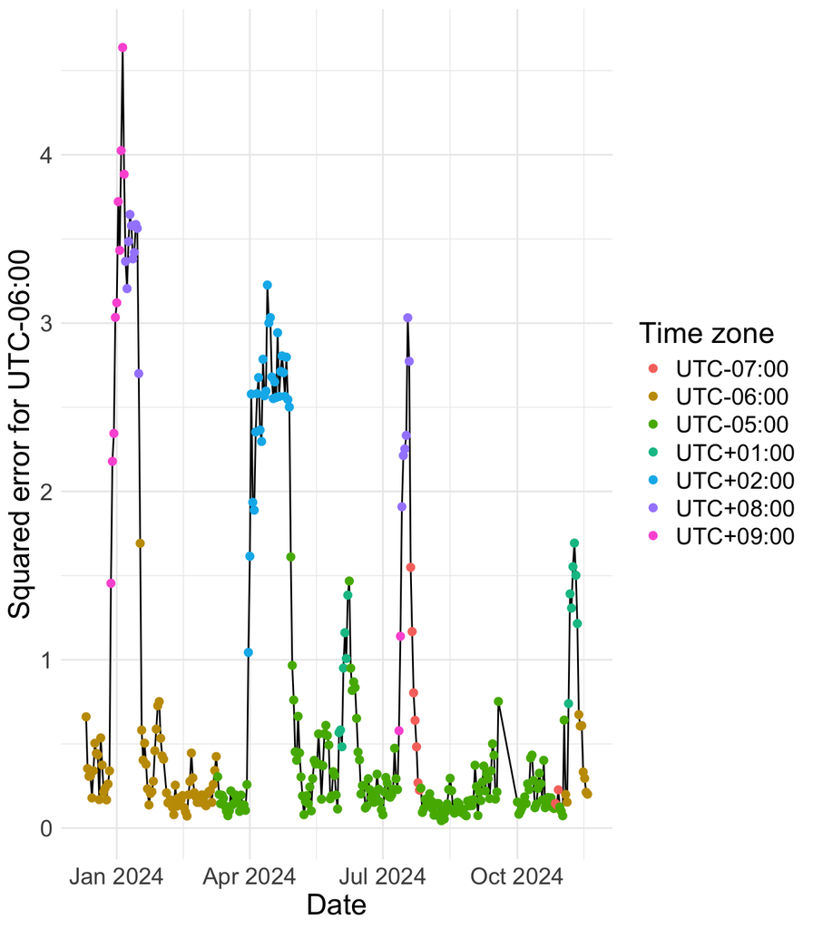

```r
ggplot(dat_svd_predict_daily, aes(date, sq_error_utc_min6)) +
  geom_line() +
  geom_point(aes(color = timezone), size = 2) +
  theme_minimal() +
  labs(x = "Date", y = "Squared error for UTC-06:00", color = "Time zone") +
  theme(text = element_text(size = 18))
```

Comparing cosine similarity and squared error of the LOESS model as phase metrics.

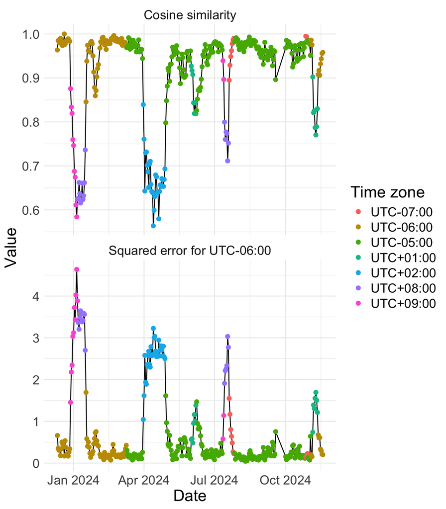

```r
tmp <- dat_svd_predict_daily %>%
  pivot_longer(c(sq_error_utc_min6, cos_sim), names_to = "variable")

ggplot(tmp, aes(date, value)) +
  geom_line() +
  geom_point(aes(color = timezone), size = 2) +
  facet_wrap(~ variable, ncol = 1, scales = "free_y",
             labeller = as_labeller(c(
               cos_sim = "Cosine similarity",
               sq_error_utc_min6 = "Squared error for UTC-06:00"
             ))) +
  theme_minimal() +
  labs(x = "Date", y = "Value", color = "Time zone") +
  theme(text = element_text(size = 18))
```

# Phase analysis

This uses the circular mean approach to calculate phase metrics. We then do a quantitative comparison between East- and Westwards travel. Follows a similar approach to `phase_analysis.Rmd`.

```r
parse_tz <- function(tz) {
  tz <- as.character(tz)
  hours <- as.integer(str_extract(tz, "[+-]\\d+"))
  minutes <- as.integer(str_match(tz, ":(\\d+)")[,2])

  hours + sign(hours) * minutes / 60
}

# Are there multiple transitions in a single day? Then merge them
consolidate_transitions <- function(df) {
  excluded <- vector("integer")

  for (i in 1:nrow(df)) {
    dtnt <- df[i, "days_to_next_transition"]
    if (!is.na(dtnt) && dtnt == 0) {
      # Move some values to the next row, then mark current row for deletion
      for (variable in c("session_timestamp", "prev_timezone", "date", "hour"))
        df[i+1, variable] <- df[i, variable]

      excluded <- c(excluded, i)
    }
  }

  df[-excluded,]
}

last_trip_length <- max(dat_ses_15$date) - max(date(dat_transition$session_timestamp))

trip_starts_alex <- dat_transition %>%
  select(!next_timestamp) %>%
  mutate(
    date = date(session_timestamp),
    hour = hour(session_timestamp),
    days_to_next_transition = lead(date) - date,
    days_to_next_transition = replace_na(days_to_next_transition, last_trip_length)
  ) %>%
  relocate(prev_timezone, .before = timezone) %>%
  consolidate_transitions() %>%
  mutate(
    diff_tz = parse_tz(timezone) - parse_tz(prev_timezone),
    # Assume travel direction corresponds to shortest distance
    diff_tz = case_when(
      abs(diff_tz) > 12 ~ -sign(diff_tz) * (24 - abs(diff_tz)),
      TRUE ~ diff_tz
    ),
    trip_id = 1:n(),
    trip_date = date
  ) %>%
  filter(days_to_next_transition >= 7) %>%
  select(!c(days_to_next_transition, session_timestamp))

trip_starts_alex
```

Trip selection logic is from phase_analysis.Rmd

```r
trips_alex_df <- dat_svd %>%
  full_join(trip_starts_alex, by = c("date", "hour")) %>%
  arrange(date, hour) %>%
  group_by(date) %>%
  fill(trip_id, trip_date, diff_tz, timezone, prev_timezone, .direction = "downup") %>%
  ungroup() %>%
  fill(trip_id, trip_date, diff_tz, timezone, prev_timezone, .direction = "down") %>%
  group_by(trip_id) %>%
  mutate(
    days_since_start = date - trip_date,
    period = "transition"
  ) %>%
  filter(days_since_start <= 7) %>%
  ungroup()

trips_alex_df
```

```r
baseline_alex_df <- dat_svd %>%
  full_join(trip_starts_alex, by = c("date", "hour")) %>%
  arrange(date, hour) %>%
  # ID might leak into other trips, so select only first 3 days
  fill(trip_id, trip_date, diff_tz, timezone, prev_timezone, .direction = "up") %>%
  group_by(trip_id) %>%
  mutate(
    days_since_start = date - trip_date,
    period = "baseline"
  ) %>%
  filter(days_since_start >= -3, days_since_start < 0) %>%
  ungroup()

baseline_alex_df
```

```r
baseline_offsets_alex <- baseline_alex_df %>%
  mutate(
    theta = hour / 24 * 2 * pi,
    x = value * cos(theta),
    y = value * sin(theta)
  ) %>%
  group_by(trip_id, date) %>%
  summarize(
    x_mean = mean(x),
    y_mean = mean(y),
    phase = atan2(y_mean, x_mean)
  ) %>%
  group_by(trip_id) %>%
  summarize(
    phase_mean = atan2(sum(sin(phase)), sum(cos(phase))),
    hour = phase_mean / (2 * pi) * 24
  ) %>%
  rename(phase_offset = phase_mean, hour_offset = hour)
baseline_offsets_alex
```

```r
trip_bl_alex_df <- trips_alex_df %>%
  bind_rows(baseline_alex_df) %>%
  arrange(trip_id, date, hour) %>%
  left_join(baseline_offsets_alex, by = c("trip_id"))

trip_bl_alex_df
```

```r
phase_alex <- trip_bl_alex_df %>%
  mutate(
    theta = hour / 24 * 2 * pi,
    # theta_local = (hour + prev_timezone / 100 + 6) %% 24 / 24 * 2 * pi,
    theta_offset = (hour - hour_offset) / 24 * 2 * pi,
    x = value * cos(theta_offset),
    y = value * sin(theta_offset)
  ) %>%
  group_by(trip_id, date) %>%
  summarize(
    x_mean = mean(x),
    y_mean = mean(y),
    phase = atan2(y_mean, x_mean),
    phase_offset = phase_offset[1],
    radius = sqrt(x_mean^2 + y_mean^2),
    days_since_start = days_since_start[1],
    diff_tz = diff_tz[1],
    period = period[1]
  ) %>%
  ungroup() %>%
  mutate(
    diff_sign = factor(sign(diff_tz), levels = c(-1, 1), labels = c("Westwards", "Eastwards")),
    days_since_start = as.numeric(days_since_start)
  ) %>%
  drop_na(phase)
phase_alex
```

```r
welch_alex <- welch_tests(phase_alex)
welch_alex
```

Phase metric over days before and since trip start, coloured by direction of travel.

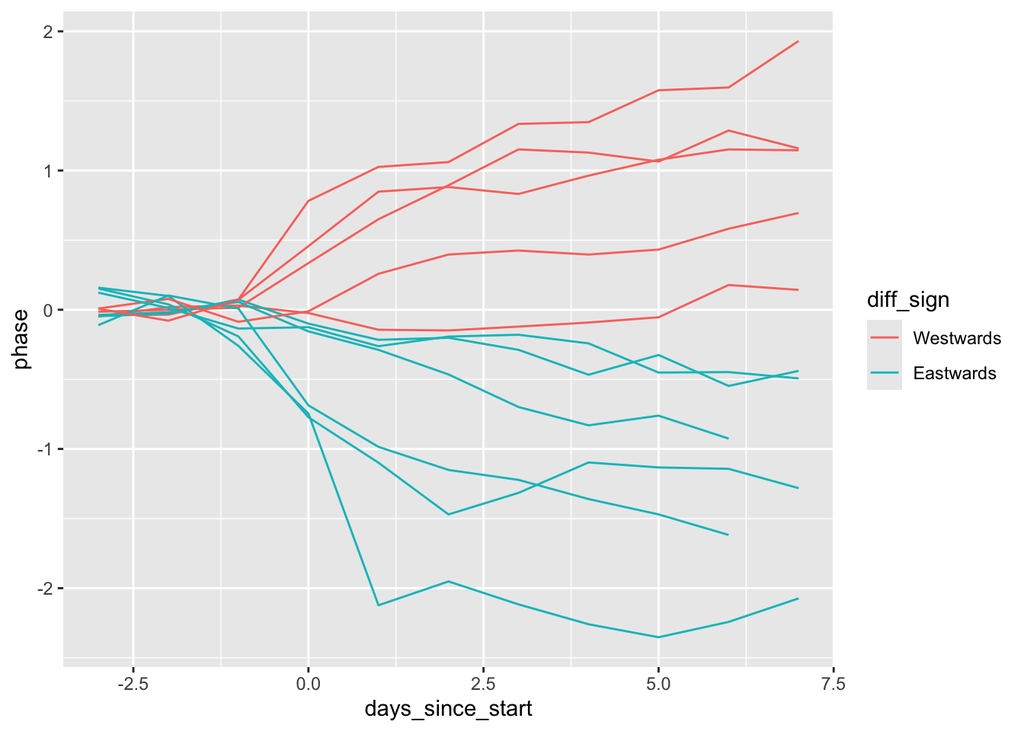

```r
ggplot(phase_alex, aes(days_since_start, phase)) +
  geom_line(aes(group = trip_id, color = diff_sign))
```

Part of Figure 3.

Original width=5, height=2.5

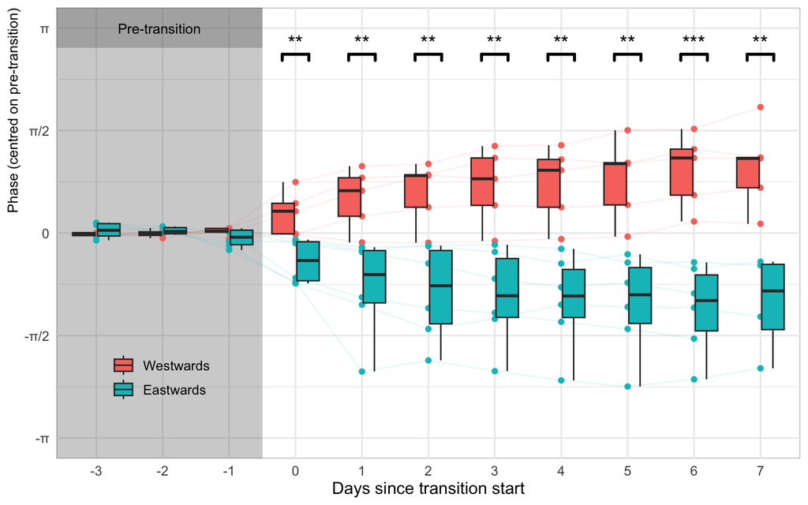

```r
gl <- guide_legend(title = NULL, position = "inside")

tmp_welch <- welch_alex %>%
  filter(p_value < 0.05)

ggplot(phase_alex, aes(as.factor(days_since_start), phase)) +
  annotate("rect", xmin = 0, xmax = 3.5, ymin = -1.5*pi, ymax = 1.5*pi, alpha = 0.3) +
  annotate("rect", xmin = 0, xmax = 3.5, ymin = pi-0.3, ymax = 1.5*pi, alpha = 0.3) +
  geom_point(aes(color = diff_sign)) + # Define x scale data type before text annotation
  geom_line(aes(color = diff_sign, group = trip_id), alpha = 0.1) +
  annotate("text", x = 1.95, y = pi, label = "Pre-transition", size = 3.5) +
  geom_boxplot(aes(fill = diff_sign), outlier.shape = NA) +
  geom_bracket(
    aes(
      xmin = days_since_start + 3.8,
      xmax = days_since_start + 4.2,
      label = stars
    ),
    y.position = pi - 0.4,
    tip.length = 0.01,
    size = 1,
    label.size = 5,
    data = tmp_welch
  ) +
  scale_y_continuous(
    breaks = c(-pi, -pi/2, 0, pi/2, pi),
    labels = c("-π", "-π/2", "0", "π/2", "π")
  ) +
  coord_cartesian(xlim = c(1, 11), ylim = c(-pi, pi), clip = "on") +
  labs(x = "Days since transition start", y = "Phase (centred on pre-transition)") +
  guides(fill = gl, color = gl) +
  theme_minimal() +
  theme(
    text = element_text(size = 12),
    axis.title.y = element_text(size = 10, hjust = 1),
    axis.title.x = element_text(size = 12),
    panel.background = element_rect(fill = "white", color = "grey"),
    legend.position.inside = c(0.14, 0.18)
  )
```

```r
# ggsave(file.path(man_img_dir, "alex_phase_analysis", "boxplots_alex_larger.pdf"),
#        device = cairo_pdf)
```

## 2nd review analysis

Here, we plot phase by time zone. We also have some experimental code for doing the phase analysis w.r.t. local time rather than a universal time zone, but the code is experimental and there are too few data to check if it works as intended.

Merge transitions that occur in a single day.

```r
dat_transition_consolidated <- dat_transition %>%
  select(!next_timestamp) %>%
  mutate(
    date = date(session_timestamp),
    hour = hour(session_timestamp),
    days_to_next_transition = lead(date) - date,
    days_to_next_transition = replace_na(days_to_next_transition, last_trip_length)
  ) %>%
  relocate(prev_timezone, .before = timezone) %>%
  consolidate_transitions()

dat_transition_consolidated
```

```r
alex_svd_tz <- dat_svd %>%
  full_join(dat_transition_consolidated, by = c("date", "hour")) %>%
  arrange(date, hour) %>%
  group_by(date) %>%
  fill(timezone, prev_timezone, .direction = "downup") %>%
  ungroup() %>%
  fill(timezone, prev_timezone, .direction = "down") %>%
  select(-c(session_timestamp, days_to_next_transition)) %>%
  drop_na(value)

alex_svd_tz
```

```r
tz_order <- c("UTC-07:00", "UTC-06:00", "UTC-05:00", "UTC+01:00", "UTC+02:00", "UTC+08:00", "UTC+09:00")

alex_phase_tz <- alex_svd_tz %>%
  mutate(
    theta = hour / 24 * 2 * pi,
    x = value * cos(theta),
    y = value * sin(theta)
  ) %>%
  group_by(date) %>%
  summarize(
    x_mean = mean(x),
    y_mean = mean(y),
    phase = atan2(y_mean, x_mean),
    radius = sqrt(x_mean^2 + y_mean^2),
    timezone = timezone[1]
  ) %>%
  drop_na(phase, timezone) %>%
  group_by(timezone) %>%
  mutate(
    n_tz_obs = n(),
    timezone = fct_relevel(timezone, !!!tz_order),
    tz_label = str_glue("{timezone}, n = {n_tz_obs}"),
    tz_label = fct_reorder(tz_label, timezone, .fun = \(tzs) parse_tz(tzs)[1])
  ) %>%
  ungroup()

alex_phase_tz
```

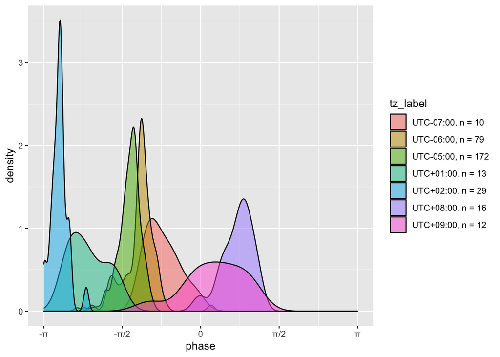

```r
ggplot(alex_phase_tz, aes(phase)) +
  geom_density(aes(fill = tz_label), position = "identity", alpha = 0.5) +
  scale_x_continuous(
    breaks = c(-pi, -pi/2, 0, pi/2, pi),
    labels = c("-π", "-π/2", "0", "π/2", "π"),
    limits = c(-pi, pi)
  )
```

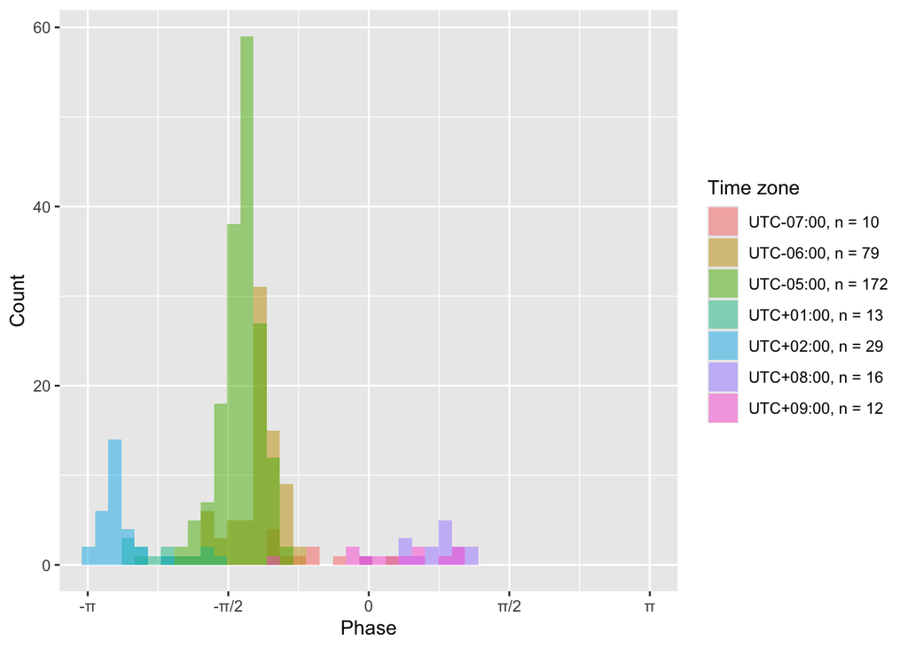

```r
ggplot(alex_phase_tz, aes(phase)) +
  geom_histogram(aes(fill = tz_label), position = "identity", alpha = 0.5) +
  scale_x_continuous(
    breaks = c(-pi, -pi/2, 0, pi/2, pi),
    labels = c("-π", "-π/2", "0", "π/2", "π")
  ) +
  coord_cartesian(xlim = c(-pi, pi)) +
  labs(x = "Phase", y = "Count", fill = "Time zone")
```

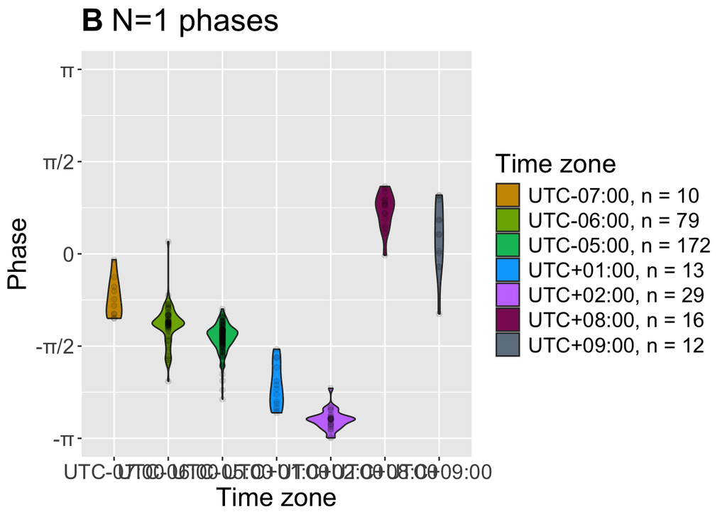

```r
gg_color_hue <- function(n) {
  hues = seq(15, 375, length = n + 1)
  hcl(h = hues, l = 65, c = 100)[1:n]
}

cols_clear3 <- gg_color_hue(n = 8)

g_phase_violin_alex <- ggplot(alex_phase_tz, aes(timezone, phase)) +
  geom_violin(aes(fill = tz_label)) +
  geom_point(alpha = 0.1) +
  scale_y_continuous(
    breaks = c(-pi, -pi/2, 0, pi/2, pi),
    labels = c("-π", "-π/2", "0", "π/2", "π"),
    limits = c(-pi, pi)
  ) +
  scale_fill_manual(
    values = c(
      cols_clear3[2:4], cols_clear3[6:7],
      "maroon4", "slategrey"
    )
  ) +
  labs(x = "Time zone", y = "Phase", fill = "Time zone",
       title = bquote(bold("B") ~ "N=1 phases")) +
  theme(text = element_text(size = 18))

g_phase_violin_alex
```

Same as a linear model, but the groups are not balanced

```r
aov_alex <- aov(phase ~ timezone, data = alex_phase_tz)

print(aov_alex)
```

```
## Call:
##    aov(formula = phase ~ timezone, data = alex_phase_tz)
##
## Terms:
##                  timezone Residuals
## Sum of Squares  180.85065  26.50526
## Deg. of Freedom         6       324
##
## Residual standard error: 0.2860181
## Estimated effects may be unbalanced
```

```r
cat("\n")
```

```r
summary(aov_alex)
```

```
##              Df Sum Sq Mean Sq F value Pr(>F)
## timezone      6 180.85  30.142   368.5 <2e-16 ***
## Residuals   324  26.51   0.082
## ---
## Signif. codes:  0 '***' 0.001 '**' 0.01 '*' 0.05 '.' 0.1 ' ' 1
```

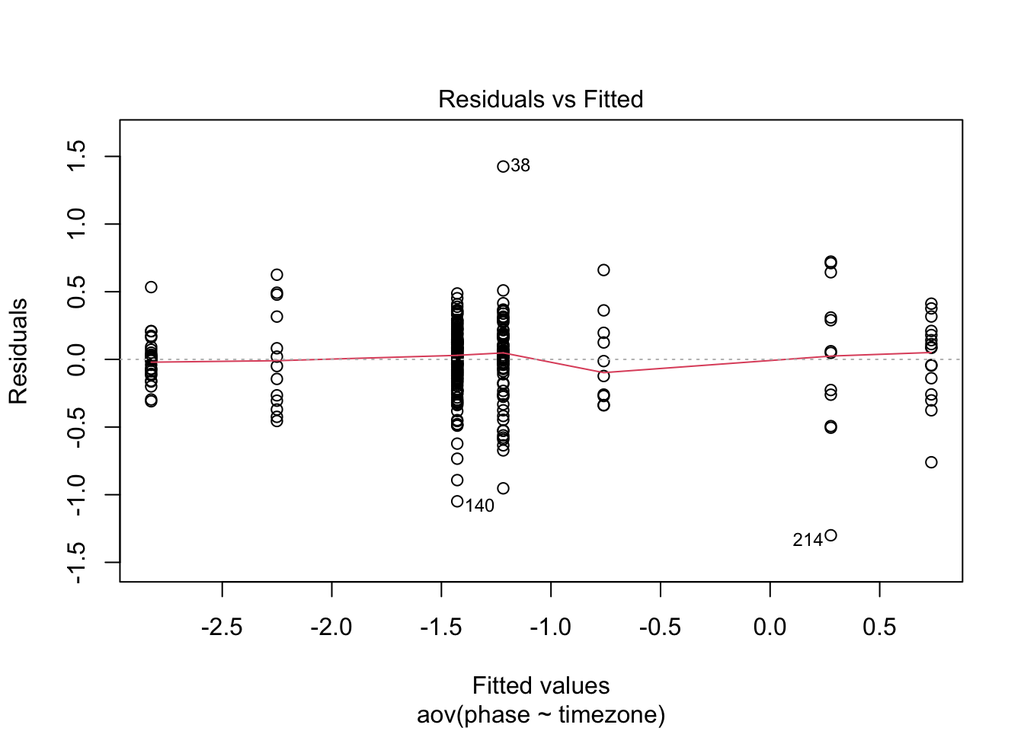

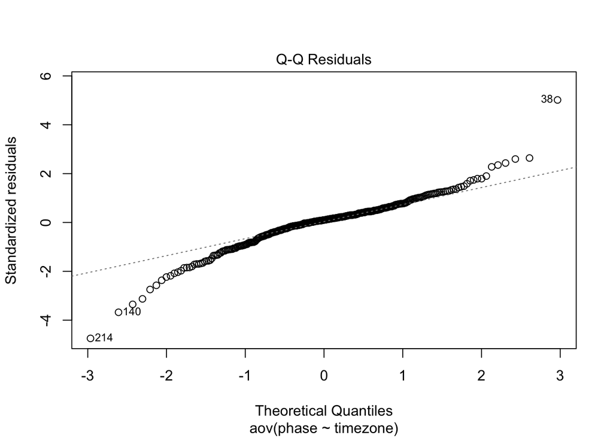

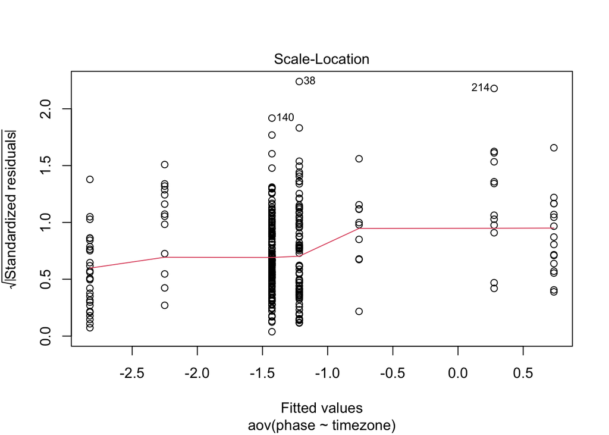

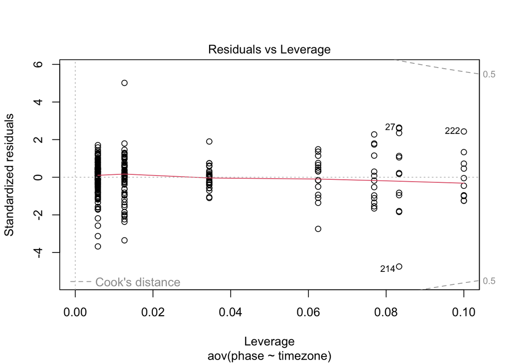

```r
plot(aov_alex)
```

```r
alex_phase_local <- alex_svd_tz %>%
  mutate(
    tz_numeric = parse_tz(timezone),
    datetime = date + hours(hour),
    # Rotate by +6 hours to move all phases to the middle of the y range
    datetime_local = datetime + hours(tz_numeric + 6),
    date_local = as_date(datetime_local),
    theta_local = hour(datetime_local) / 24 * 2 * pi,
    x_local = value * cos(theta_local),
    y_local = value * sin(theta_local)
  ) %>%
  group_by(date_local) %>%
  # The time zone shift can result in incomplete days, which skew the phase
  filter(n() == 24) %>%
  summarize(
    x_mean_local = mean(x_local),
    y_mean_local = mean(y_local),
    phase_local = atan2(y_mean_local, x_mean_local),
    radius_local = sqrt(x_mean_local^2 + y_mean_local^2),
    timezone = timezone[1],
    tz_numeric = tz_numeric[1]
  ) %>%
  drop_na(phase_local, timezone) %>%
  group_by(timezone) %>%
  mutate(
    n_tz_obs = n(),
    timezone = fct_relevel(timezone, !!!tz_order),
    tz_label = str_glue("{timezone}, n = {n_tz_obs}"),
    tz_label = fct_reorder(tz_label, timezone, .fun = \(tzs) parse_tz(tzs)[1])
  ) %>%
  ungroup()

alex_phase_local
```

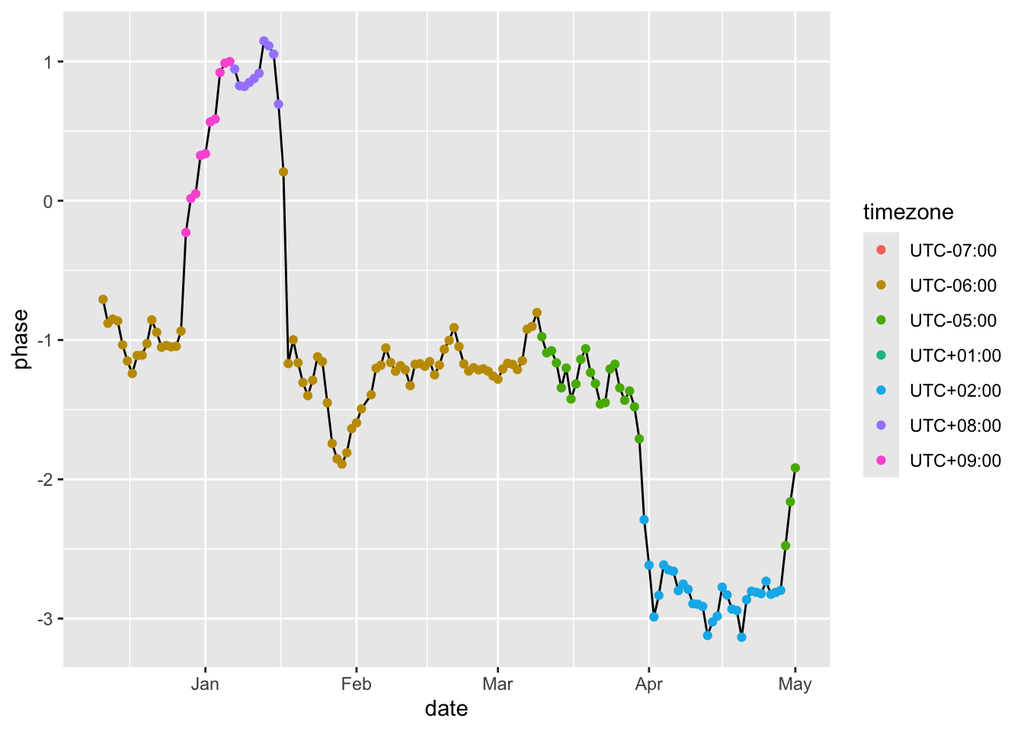

```r
ggplot(alex_phase_tz, aes(date, phase)) +
  geom_line() +
  geom_point(aes(color = timezone)) +
  scale_x_date(limits = c(ymd("2023-12-10"), ymd("2024-05-01")))
```

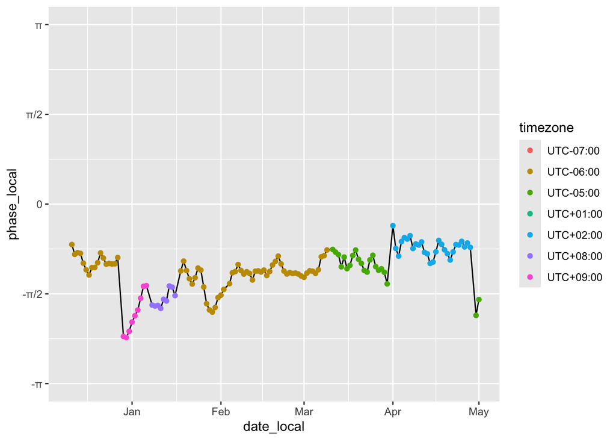

```r
ggplot(alex_phase_local, aes(date_local, phase_local)) +
  geom_line() +
  geom_point(aes(color = timezone)) +
  scale_x_date(limits = c(ymd("2023-12-10"), ymd("2024-05-01"))) +
  scale_y_continuous(
    breaks = c(-pi, -pi/2, 0, pi/2, pi),
    labels = c("-π", "-π/2", "0", "π/2", "π"),
    limits = c(-pi, pi)
  )
```